# Prediction Assignment

Vimal Natarajan

June 5, 2016

## Introduction

Using devices such as Jawbone Up, Nike FuelBand, and Fitbit it is now possible to collect a large amount of data about personal activity relatively inexpensively. These type of devices are part of the quantified self movement - a group of enthusiasts who take measurements about themselves regularly to improve their health, to find patterns in their behavior, or because they are tech geeks. One thing that people regularly do is quantify how much of a particular activity they do, but they rarely quantify how well they do it. In this project, your goal will be to use data from accelerometers on the belt, forearm, arm, and dumbell of 6 participants. They were asked to perform barbell lifts correctly and incorrectly in 5 different ways. More information is available from the website here: http://groupware.les.inf.puc-rio.br/har (see the section on the Weight Lifting Exercise Dataset).

## Data

The training data for this project are available here:

https://d396qusza40orc.cloudfront.net/predmachlearn/pml-training.csv

The test data are available here:

https://d396qusza40orc.cloudfront.net/predmachlearn/pml-testing.csv

The data for this project come from this source: http://groupware.les.inf.puc-rio.br/har. If you use the document you create for this class for any purpose please cite them as they have been very generous in allowing their data to be used for this kind of assignment.

## Goal

The goal of your project is to predict the manner in which they did the exercise. This is the “classe” variable in the training set.

## Data Processing

The outcome variable is the “classe” variable, a factor variable with 5 levels. The participants were asked to perform one set of 10 repetitions of the Unilateral Dumbbell Biceps Curl in 5 different ways:

Class A: exactly according to the specification Class B: throwing the elbows to the front Class C: lifting the dumbbell only halfway Class D: lowering the dumbbell only halfway Class E: throwing the hips to the front

### Getting data

Getting the training and testing data.

```r
training <- read.csv("pml-training.csv", na.strings=c("NA","#DIV/0!",""))
testing <- read.csv("pml-testing.csv", na.strings=c("NA","#DIV/0!",""))
```

### Delete columns with all missing values

```r
training<-training[,colSums(is.na(training)) == 0]
testing <-testing[,colSums(is.na(testing)) == 0]
```

### Remove unwanted columns

Some columns namely user_name,raw_timestamp_part_1,raw_timestamp_part_2,cvtd_timestamp,new_window, num_window are not relevant here and can be removed.

```r
training   <-training[,-c(1:7)]
testing <-testing[,-c(1:7)]
```

## Cross validation

To perform cross validation, the training data is split into two, with 70% of the data for sub-training and 30% for sub-testing. Once the model is tested against this sub-testing data, then it will again be tested against the testing data.

### Partioning the training set into two

Partioning Training data set into two data sets, 70% for mytraining, 30% for mytesting:

```r
inTrain <- createDataPartition(y=training$classe, p=0.7, list=FALSE)
mytraining <- training[inTrain, ]
mytesting <- training[-inTrain, ]
dim(mytraining)
```

```
## [1] 13737    53
```

```r
dim(mytesting)
```

```
## [1] 5885   53
```

## Choosing models

Two models, namely Decision Tree and RandomForest, will be used for testing. The model with highest accuracy will be used as final model.

### ML Algorithm 1: Decision Tree

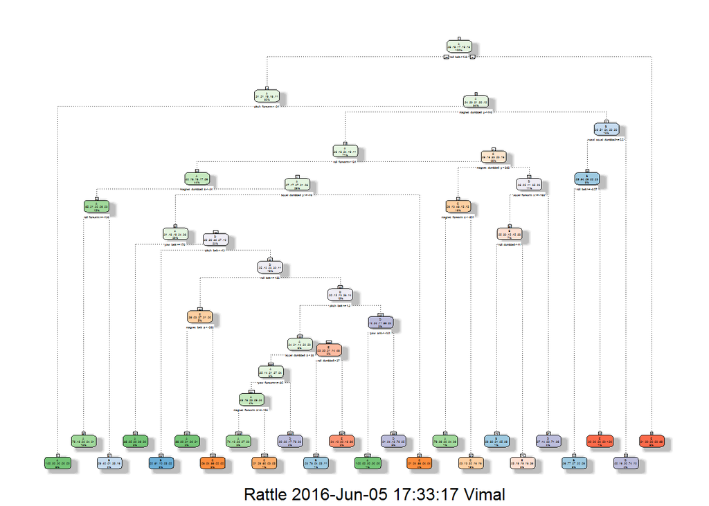

```r
modelFit_DT <- rpart(classe ~ ., data=mytraining, method="class")
fancyRpartPlot(modelFit_DT)
```

#### Prediction on ML using Decision Tree

```r
predictions_DT <- predict(modelFit_DT, mytesting, type = "class")
confusionMatrix(predictions_DT, mytesting$classe)
```

```
## Confusion Matrix and Statistics
##
##           Reference
## Prediction    A    B    C    D    E
##          A 1526  168   27   60   15
##          B   52  648   58   74   78
##          C   51  156  818  134  134
##          D   16   72   58  632   64
##          E   29   95   65   64  791
##
## Overall Statistics
##
##                Accuracy : 0.7502
##                  95% CI : (0.7389, 0.7612)
##     No Information Rate : 0.2845
##     P-Value [Acc > NIR] : < 2.2e-16
##
##                   Kappa : 0.6834
##  Mcnemar's Test P-Value : < 2.2e-16
##
## Statistics by Class:
##
##                      Class: A Class: B Class: C Class: D Class: E
## Sensitivity            0.9116   0.5689   0.7973   0.6556   0.7311
## Specificity            0.9359   0.9448   0.9022   0.9573   0.9473
## Pos Pred Value         0.8497   0.7121   0.6326   0.7506   0.7577
## Neg Pred Value         0.9638   0.9013   0.9547   0.9342   0.9399
## Prevalence             0.2845   0.1935   0.1743   0.1638   0.1839
## Detection Rate         0.2593   0.1101   0.1390   0.1074   0.1344
## Detection Prevalence   0.3052   0.1546   0.2197   0.1431   0.1774
## Balanced Accuracy      0.9237   0.7569   0.8498   0.8065   0.8392
```

### ML Algorithm 2: Random Forest

```r
modelFit_RF <- randomForest(classe ~ ., data=mytraining, method = "class")
```

#### Prediction on ML using Random Forest

```r
predictions_RF <- predict(modelFit_RF, mytesting, type = "class")
confusionMatrix(predictions_RF, mytesting$classe)
```

```
## Confusion Matrix and Statistics
##
##           Reference
## Prediction    A    B    C    D    E
##          A 1673    3    0    0    0
##          B    0 1133    5    0    0
##          C    0    3 1021    6    2
##          D    0    0    0  956    1
##          E    1    0    0    2 1079
##
## Overall Statistics
##
##                Accuracy : 0.9961
##                  95% CI : (0.9941, 0.9975)
##     No Information Rate : 0.2845
##     P-Value [Acc > NIR] : < 2.2e-16
##
##                   Kappa : 0.9951
##  Mcnemar's Test P-Value : NA
##
## Statistics by Class:
##
##                      Class: A Class: B Class: C Class: D Class: E
## Sensitivity            0.9994   0.9947   0.9951   0.9917   0.9972
## Specificity            0.9993   0.9989   0.9977   0.9998   0.9994
## Pos Pred Value         0.9982   0.9956   0.9893   0.9990   0.9972
## Neg Pred Value         0.9998   0.9987   0.9990   0.9984   0.9994
## Prevalence             0.2845   0.1935   0.1743   0.1638   0.1839
## Detection Rate         0.2843   0.1925   0.1735   0.1624   0.1833
## Detection Prevalence   0.2848   0.1934   0.1754   0.1626   0.1839
## Balanced Accuracy      0.9993   0.9968   0.9964   0.9957   0.9983
```

### Decision on model

Comparing the two models, it is clear that the Random Forest model is better in accuracy than the Decision Tree, so Random Forest will be used for the final testing.

## Submission

```r
final_prediction <- predict(modelFit_RF, testing, type="class")
final_prediction
```

```
##  1  2  3  4  5  6  7  8  9 10 11 12 13 14 15 16 17 18 19 20
##  B  A  B  A  A  E  D  B  A  A  B  C  B  A  E  E  A  B  B  B
## Levels: A B C D E
```